# Graph Networks Activity

### Visualizing the Network

Now that the basic elements of a graph network are understood, it’s time to visualize them. One way to do this is by making an ego graph, which centers around a single node, the ego.

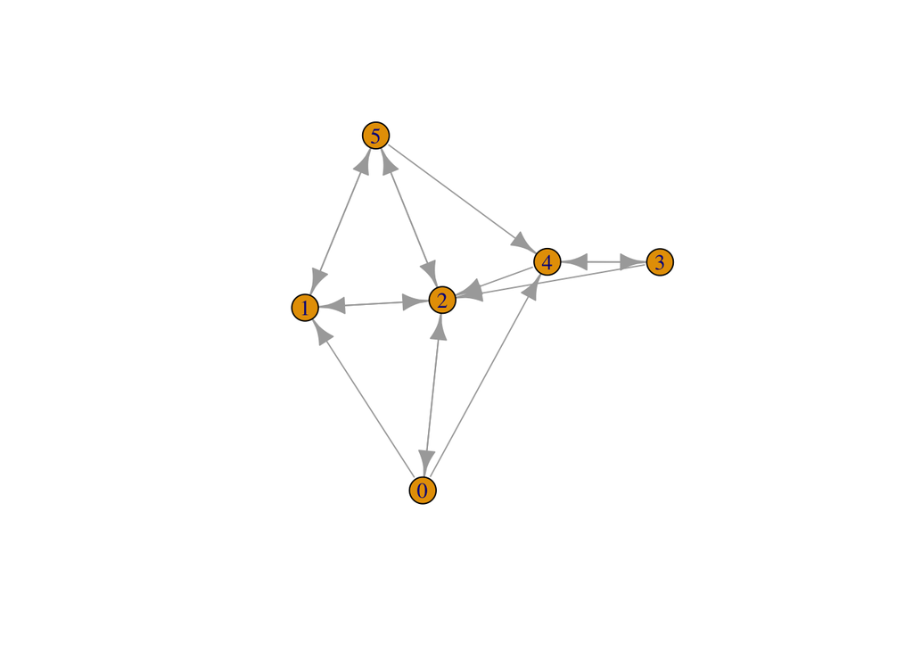

```r
graph_ego <- make_ego_graph(graph, 3, '0', mode = c('all'))[[1]]
fr_graph_ego <- make_ego_graph(friends_graph, 1, 'Joey', mode = c('all'))[[1]]
plot(graph_ego)
```

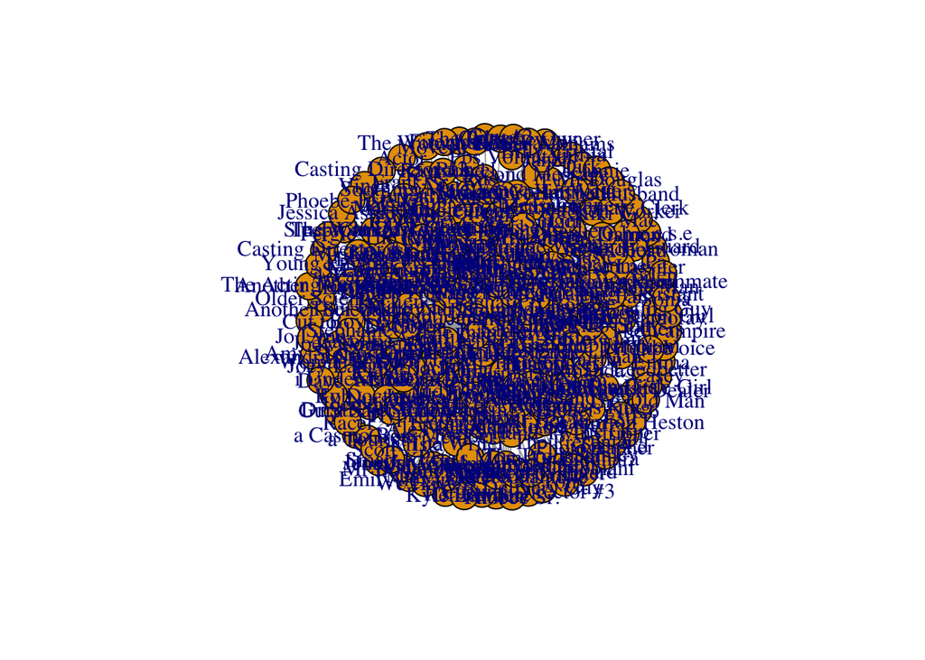

```r
plot(fr_graph_ego)
```

As you can see, this still produces results that are not particularly helpful, especially for the monstrous Friends netowork. At the very least, we can add some colors to the homemade data that indicate each node’s proximity to the ego, number zero (the Friends network will take a little more).

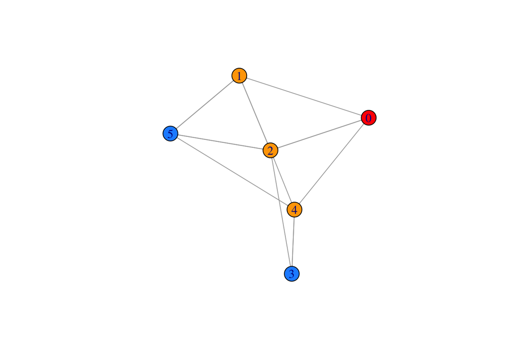

```r
colors <- c("red", "orange","dodgerblue", "cyan")
dists <- distances(graph_ego, v = '0')
V(graph_ego)$color <- colors[dists+1]
plot(graph_ego, edge.arrow.size = .05)
```

For the Friends graph, we’ll use the louvain_cluster command to organize the network into distinct communities, and assign those communities to the graph object to encourage additional organization. Then, we’ll create subgraphs out of each community so they can be analyzed independently and sorted using dplyr commands for analyzing the nodes with the most betweenness, or involvement within the network. The resulting list will show each community’s member count and its most central member.

```r
# run louvain with edge weights
louvain_partition <- igraph::cluster_louvain(friends_graph, weights = E(friends_graph)$weight)
# assign communities to graph
friends_graph$community <- louvain_partition$membership
# see how many communities there are
unique(friends_graph$community)
```

```
## [1] 4 6 1 7 3 8 5 2
```

```r
communities <- data.frame()
for (i in unique(friends_graph$community)) {
  # create subgraphs for each community
  subgraph <- induced_subgraph(friends_graph, v = which(friends_graph$community == i))
  # get size of each subgraph
  size <- igraph::gorder(subgraph)
  # get betweenness centrality
  btwn <- igraph::betweenness(subgraph)
  communities <- communities %>%
    dplyr::bind_rows(data.frame(
      community = i,
      n_characters = size,
      most_important = names(which(btwn == max(btwn)))
    )
    )
}
knitr::kable(
  communities %>%
    dplyr::select(community, n_characters, most_important))
```

| community | n_characters | most_important |
| --- | --- | --- |
| 4 | 128 | Chandler |
| 6 | 109 | Joey |
| 1 | 105 | Phoebe |
| 7 | 93 | Rachel |
| 3 | 105 | Monica |
| 8 | 94 | Ross |
| 5 | 8 | Intercom |
| 2 | 8 | Bandleader |
| 2 | 8 | Dennis Phillips |

```r
top_five <- data.frame()
for (i in unique(friends_graph$community)) {
  # create subgraphs for each community
  subgraph <- induced_subgraph(friends_graph, v = which(friends_graph$community == i))
  # for larger communities
  if (igraph::gorder(subgraph) > 20) {
    # get degree
    degree <- igraph::degree(subgraph)
  }
}
```

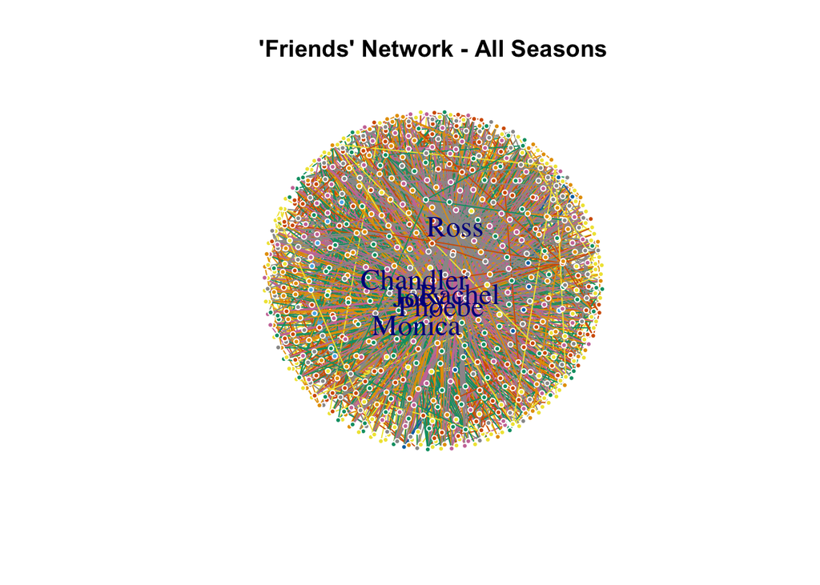

```r
# Scaling by degree and coloring by community
V(friends_graph)$size <- 3
V(friends_graph)$frame.color <- "white"
V(friends_graph)$color <- friends_graph$community
V(friends_graph)$label <- V(friends_graph)$name
V(friends_graph)$label.cex <- 1.5
# Coloring by speaker
edge.start <- ends(friends_graph, es = E(friends_graph), names = F)[,1]
E(friends_graph)$color <- V(friends_graph)$color[edge.start]
E(friends_graph)$arrow.mode <- 0 # only label central characters
v_labels <- which(V(friends_graph)$name %in% friends)
for (i in 1:length(V(friends_graph))) {
  if (!(i %in% v_labels)) { V(friends_graph)$label[i] <- "" }
}

l1 <- layout_on_sphere(friends_graph)
plot(friends_graph, rescale = T, layout = l1, main = "'Friends' Network - All Seasons")
```

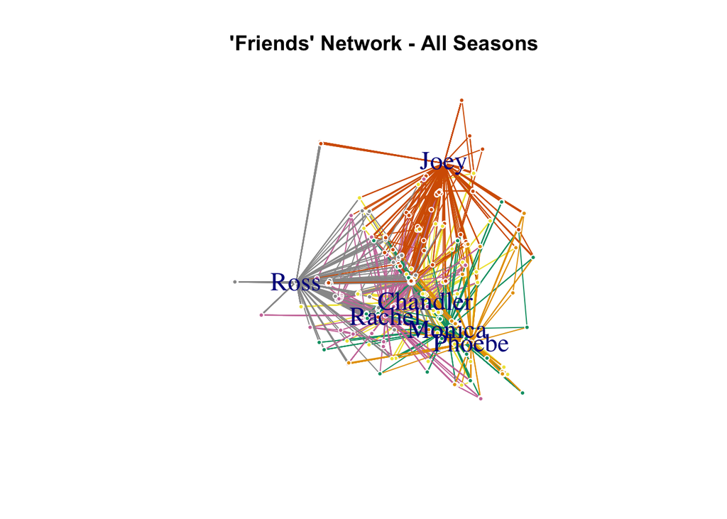

```r
l2 <- layout_with_mds(friends_graph)
plot(friends_graph, rescale = T, layout = l2, main = "'Friends' Network - All Seasons")
```

### Acknowledgements

Special thanks to Keith McNulty’s article “Community Detection in R Using Communitues of Friends Characters” for adding some popular culture to this activity.